# SEACAR SAV Analysis

Last compiled on 03 August, 2026

# Important Notes

The purpose of this script is to provide a report summary of SAV analysis. The script used for analysis is SEACAR_SAV_BB_script_website.R.

All scripts and outputs can be found on the SEACAR GitHub repository:

https://github.com/FloridaSEACAR/SEACAR_Trend_Analyses

This script is based off of code originally written by Stephen Durham with comments by Marcus W. Beck. Modified by Tyler Hill.

The file being used for the analysis is: **All_SAV_Parameters-2026-Jun-04.txt**

# Alligator Harbor Aquatic Preserve

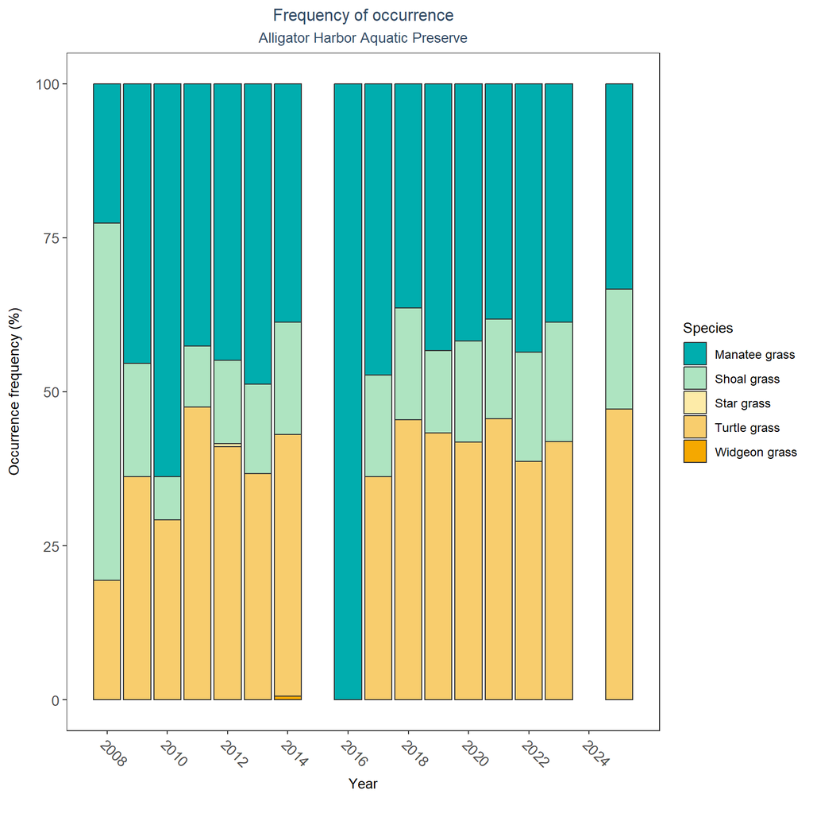

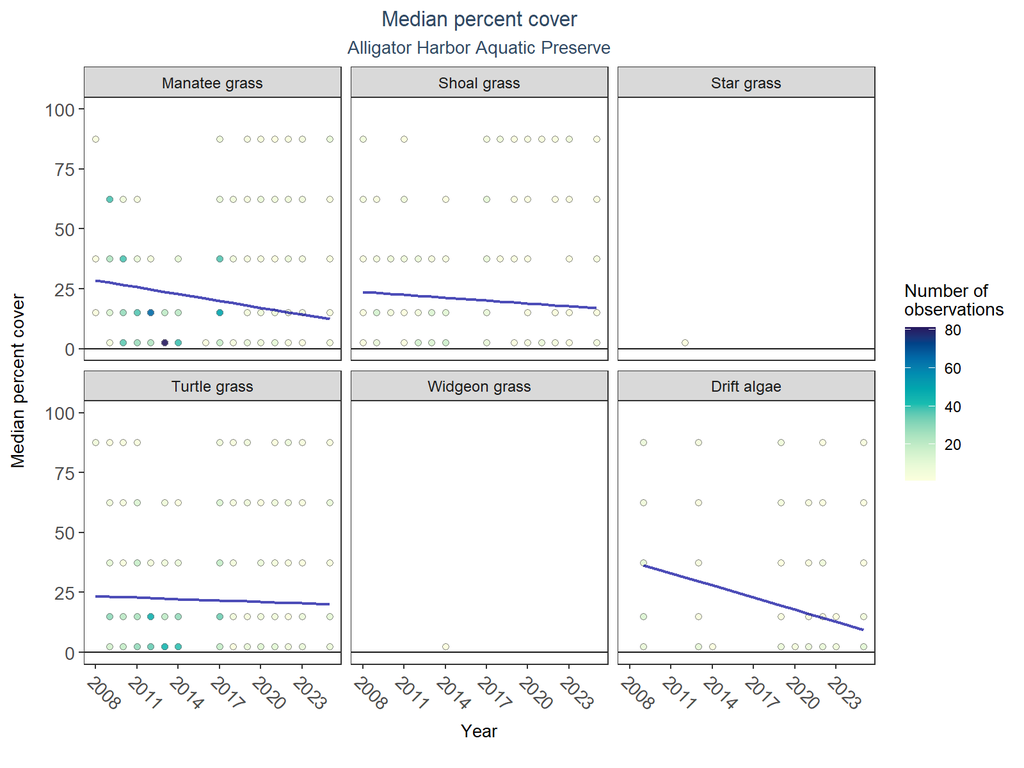

SAV LME Results for Alligator Harbor Aquatic Preserve

| Species | Statistical Trend | Period of Record | LME Intercept | LME Slope | p |
| --- | --- | --- | --- | --- | --- |
| Drift algae | Decreasing trend | 2009 - 2025 | 61.87 | -1.70 | 0.02 |
| Shoal grass | No detectable trend | 2008 - 2025 | 29.30 | -0.40 | 0.49 |
| Star grass | Insufficient data | 2012 - 2012 | - | - | - |
| Widgeon grass | Insufficient data | 2014 - 2014 | - | - | - |
| Manatee grass | No detectable trend | 2008 - 2025 | 41.95 | -0.96 | 0.08 |
| Turtle grass | No detectable trend | 2008 - 2025 | 26.30 | -0.20 | 0.72 |

An annual decrease in percent cover was observed for drift algae (-1.70%). Manatee grass, shoal grass, and turtle grass showed no detectable change in percent cover. Trends in percent cover could not be evaluated for star grass and widgeon grass due to insufficient data.

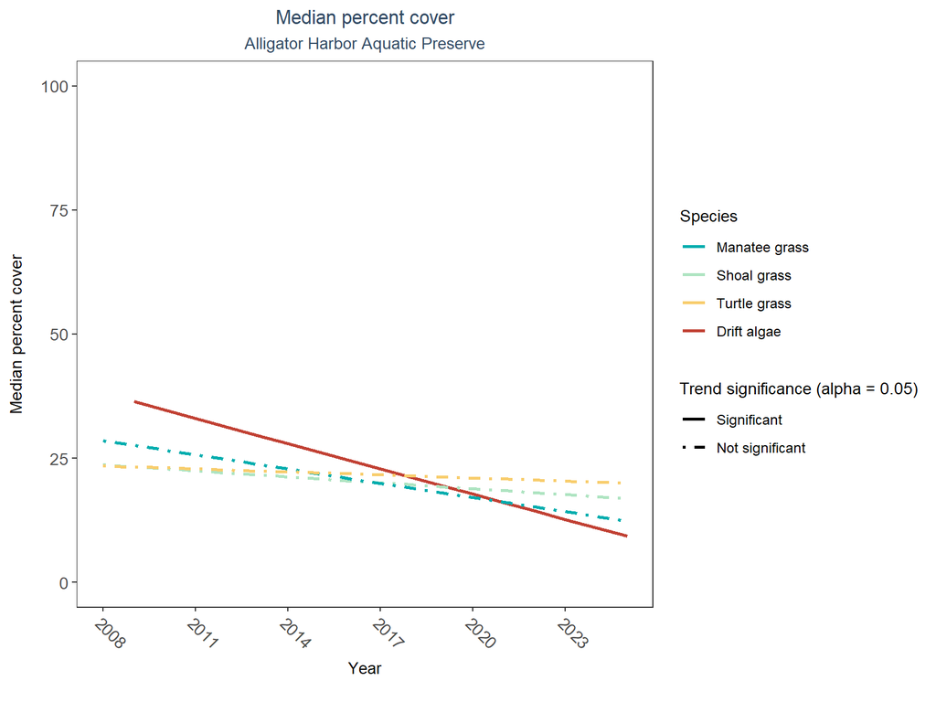

[figure not shown]

Map showing SAV sampling sites within the boundaries of *Alligator Harbor Aquatic Preserve*. The point size reflects the number of samples at a given sampling site.

# Apalachicola Bay Aquatic Preserve

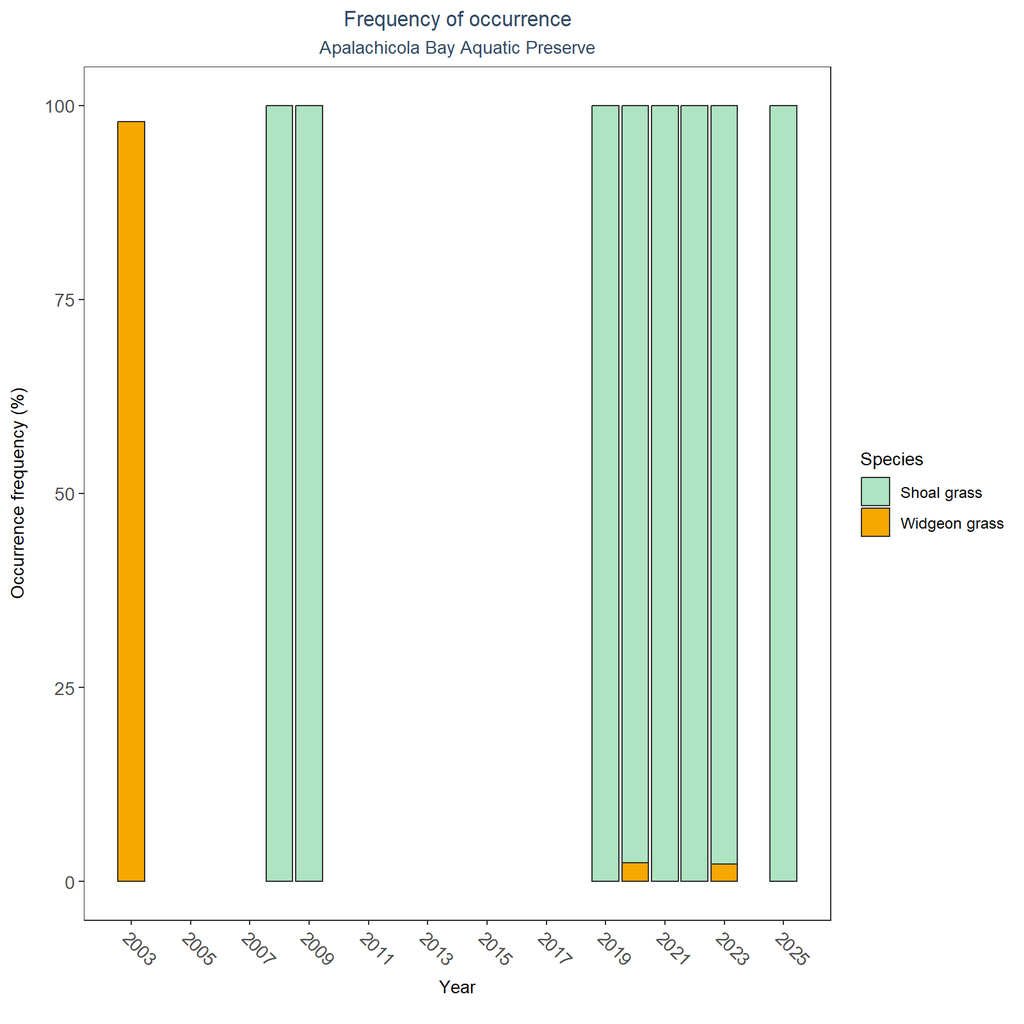

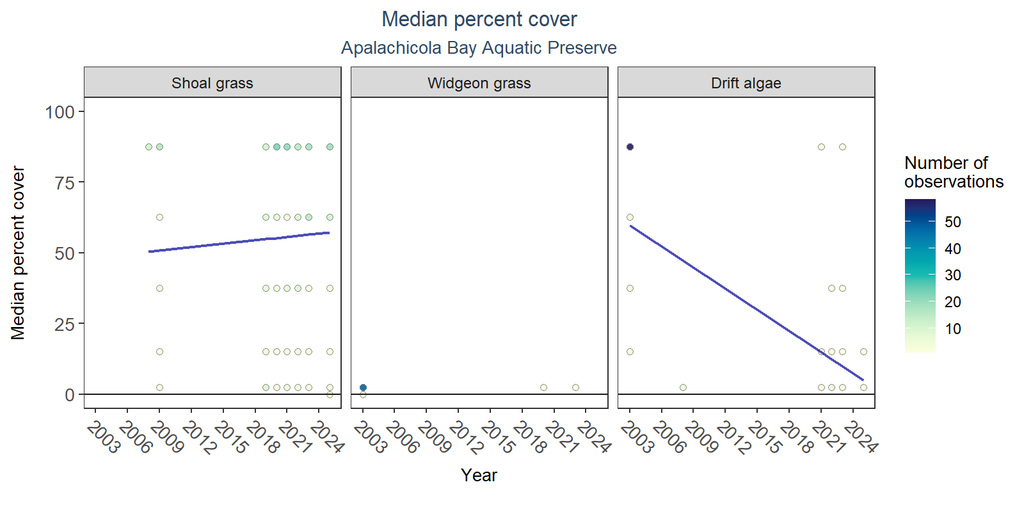

SAV LME Results for Apalachicola Bay Aquatic Preserve

| Species | Statistical Trend | Period of Record | LME Intercept | LME Slope | p |
| --- | --- | --- | --- | --- | --- |
| Drift algae | Decreasing trend | 2003 - 2025 | 82.06 | -2.49 | 0.0 |
| Shoal grass | No detectable trend | 2008 - 2025 | 44.92 | 0.40 | 0.7 |
| Widgeon grass | Insufficient data | 2003 - 2023 | - | - | - |

An annual decrease in percent cover was observed for drift algae (-2.49%). No detectable change in percent cover was observed for shoal grass. Trends in percent cover could not be evaluated for widgeon grass due to insufficient data.

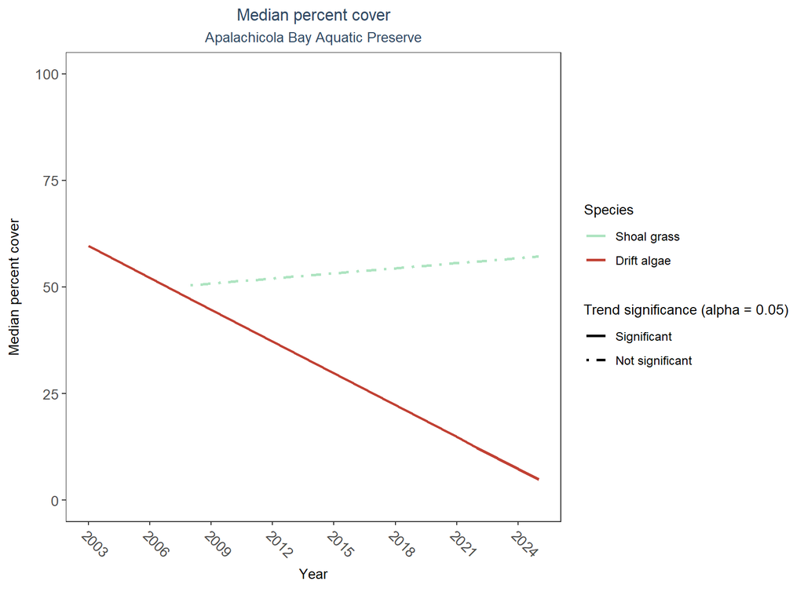

[figure not shown]

Map showing SAV sampling sites within the boundaries of *Apalachicola Bay Aquatic Preserve*. The point size reflects the number of samples at a given sampling site.

# Apalachicola National Estuarine Research Reserve

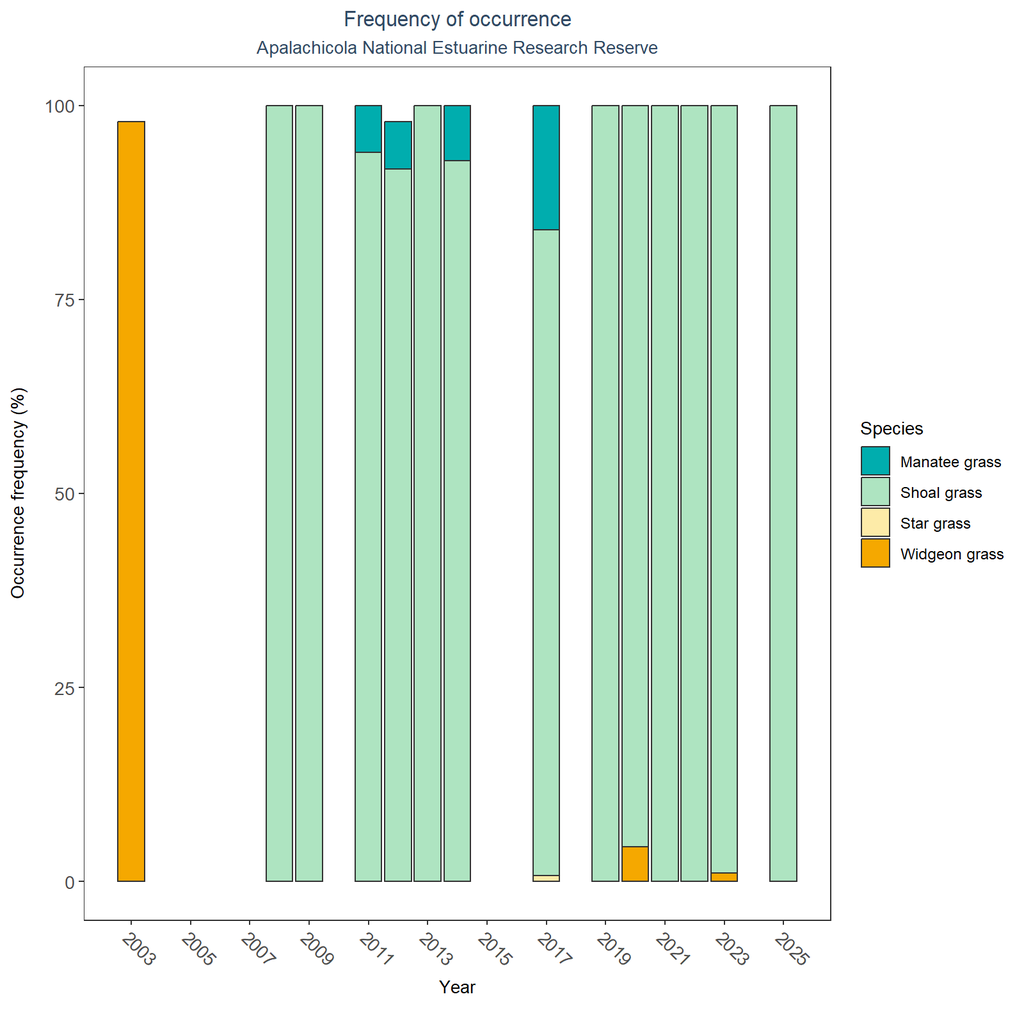

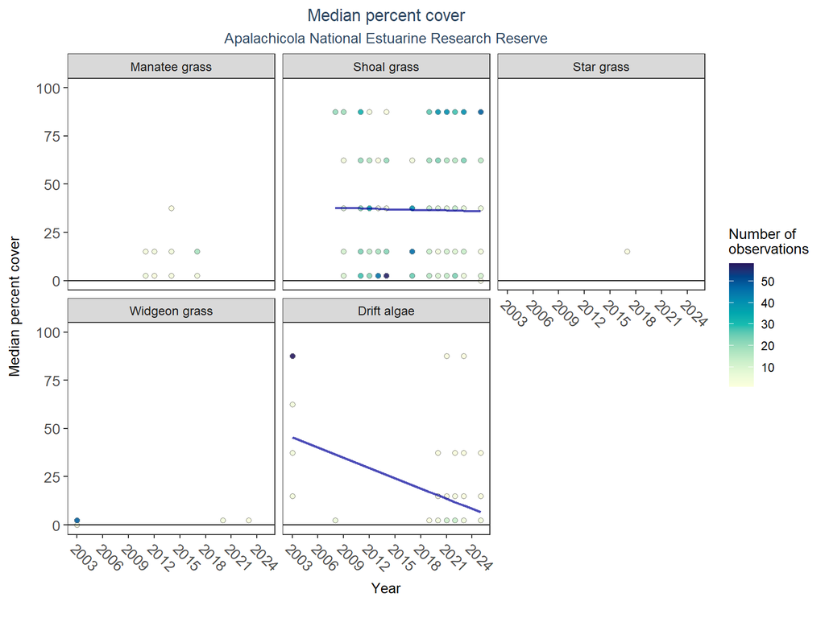

SAV LME Results for Apalachicola National Estuarine Research Reserve

| Species | Statistical Trend | Period of Record | LME Intercept | LME Slope | p |
| --- | --- | --- | --- | --- | --- |
| Drift algae | Decreasing trend | 2003 - 2025 | 61.41 | -1.77 | 0.02 |
| Shoal grass | No detectable trend | 2008 - 2025 | 39.25 | -0.11 | 0.86 |
| Star grass | Insufficient data | 2017 - 2017 | - | - | - |
| Widgeon grass | Insufficient data | 2003 - 2023 | - | - | - |
| Manatee grass | Insufficient data | 2011 - 2017 | - | - | - |

An annual decrease in percent cover was observed for drift algae (-1.77%). No detectable change in percent cover was observed for shoal grass. Trends in percent cover could not be evaluated for manatee grass, star grass, and widgeon grass due to insufficient data.

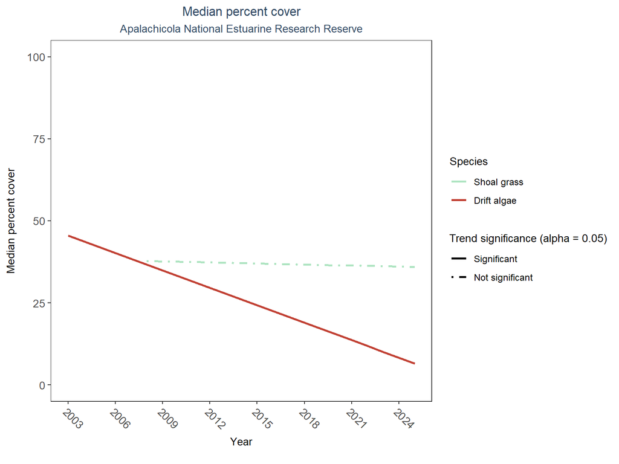

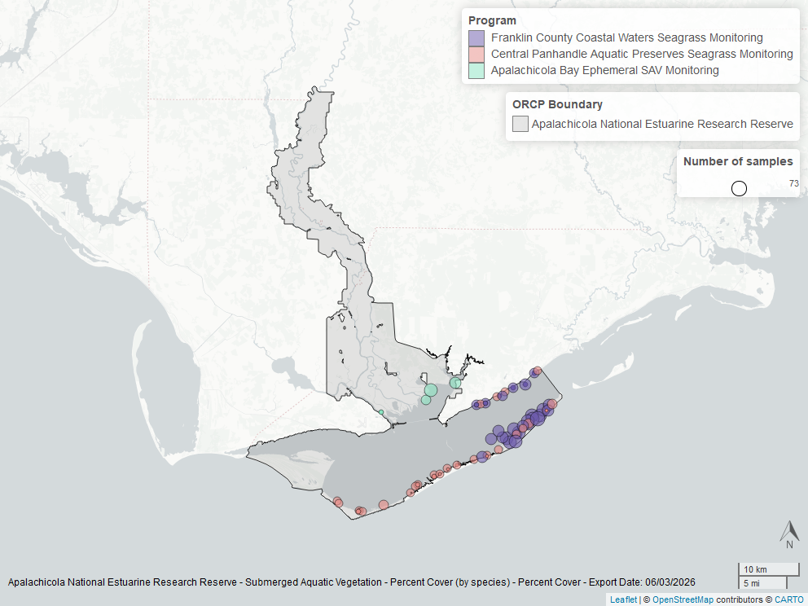

Map showing SAV sampling sites within the boundaries of *Apalachicola National Estuarine Research Reserve*. The point size reflects the number of samples at a given sampling site.

# Banana River Aquatic Preserve

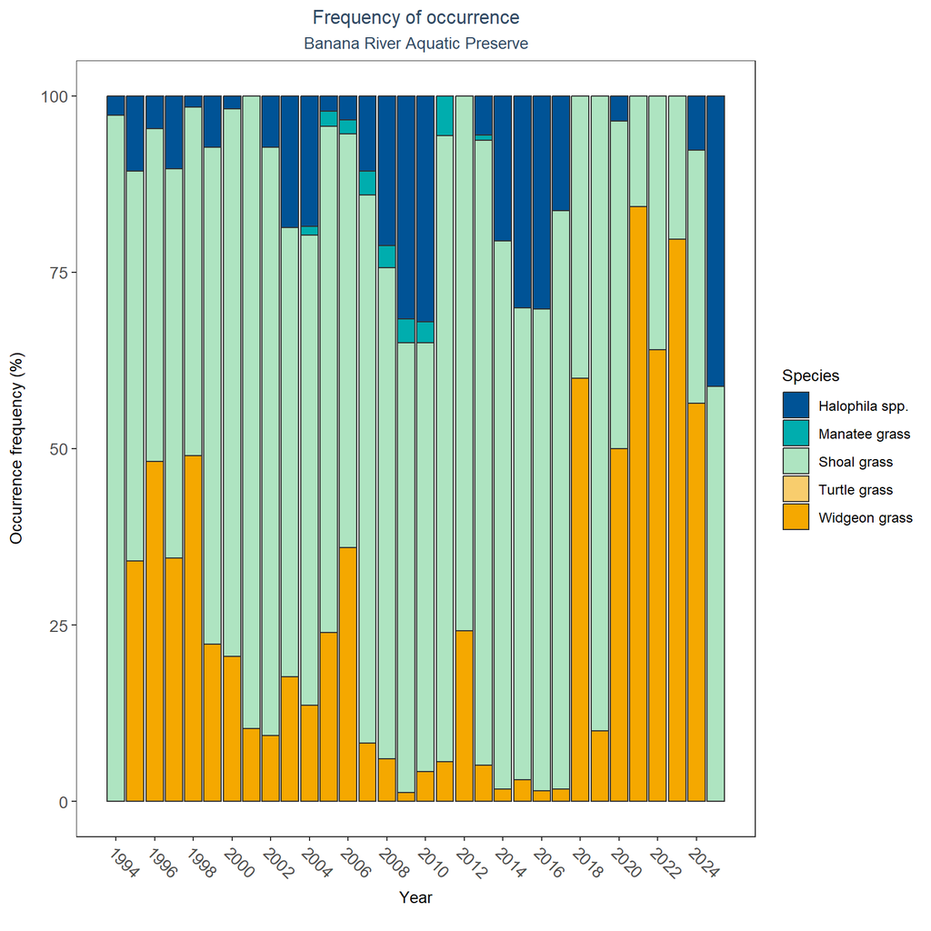

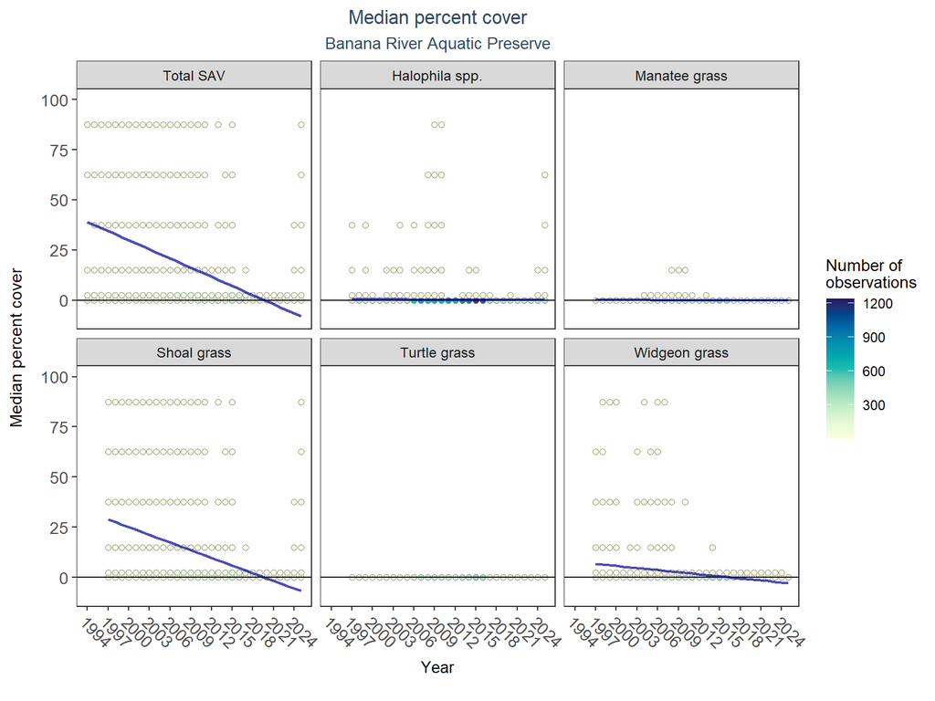

SAV LME Results for Banana River Aquatic Preserve

| Species | Statistical Trend | Period of Record | LME Intercept | LME Slope | p |
| --- | --- | --- | --- | --- | --- |
| Shoal grass | Decreasing trend | 1997 - 2025 | 32.71 | -1.27 | 0.00 |
| Halophila spp. | No detectable trend | 1997 - 2025 | 0.50 | -0.01 | 0.14 |
| Widgeon grass | Decreasing trend | 1997 - 2025 | 7.80 | -0.34 | 0.00 |
| Manatee grass | No detectable trend | 1997 - 2025 | 0.09 | 0.00 | 0.07 |
| Turtle grass | Model did not fit the available data | 1997 - 2025 | - | - | - |
| Total SAV | Decreasing trend | 1994 - 2025 | 39.07 | -1.52 | 0.00 |

Annual decreases in percent cover were observed for total SAV (-1.52%), shoal grass (-1.27%), and widgeon grass (-0.34%). No detectable change in percent cover was observed for *Halophila* spp. and manatee grass. The model could not be fitted for turtle grass.

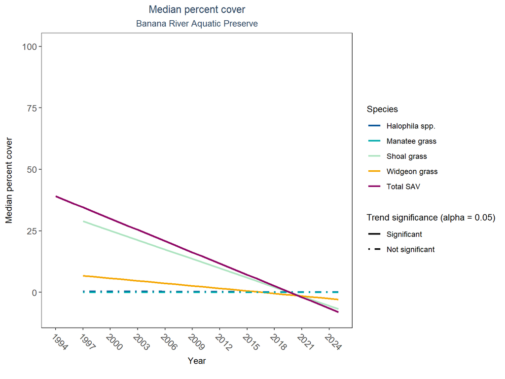

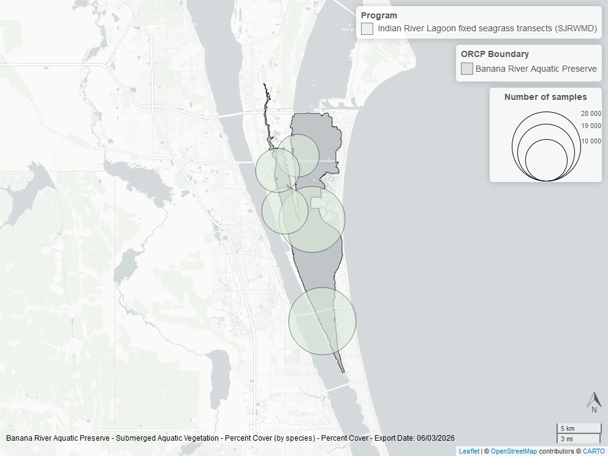

Map showing SAV sampling sites within the boundaries of *Banana River Aquatic Preserve*. The point size reflects the number of samples at a given sampling site.

# Big Bend Seagrasses Aquatic Preserve

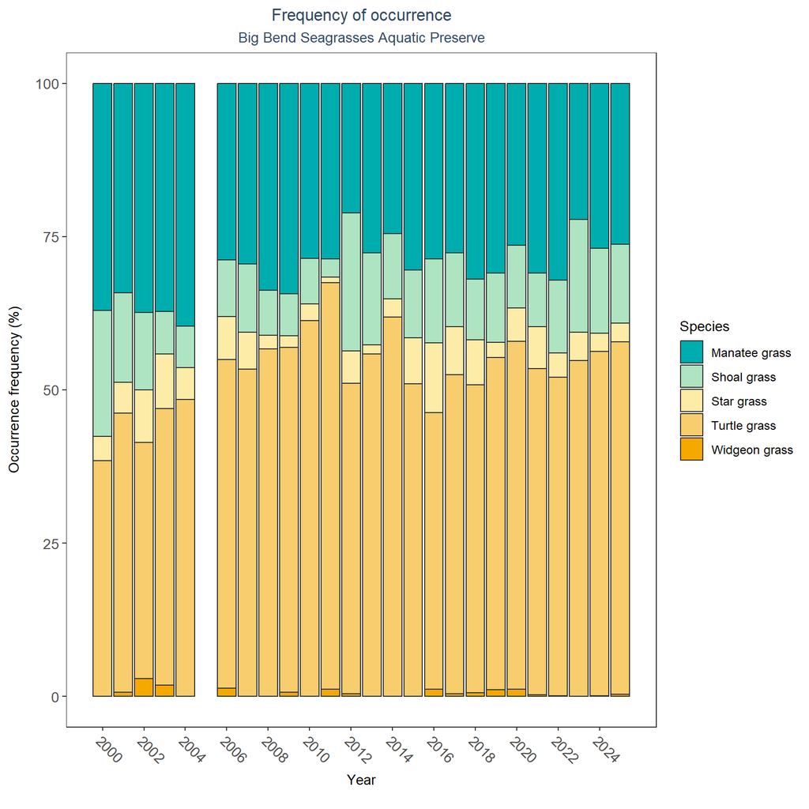

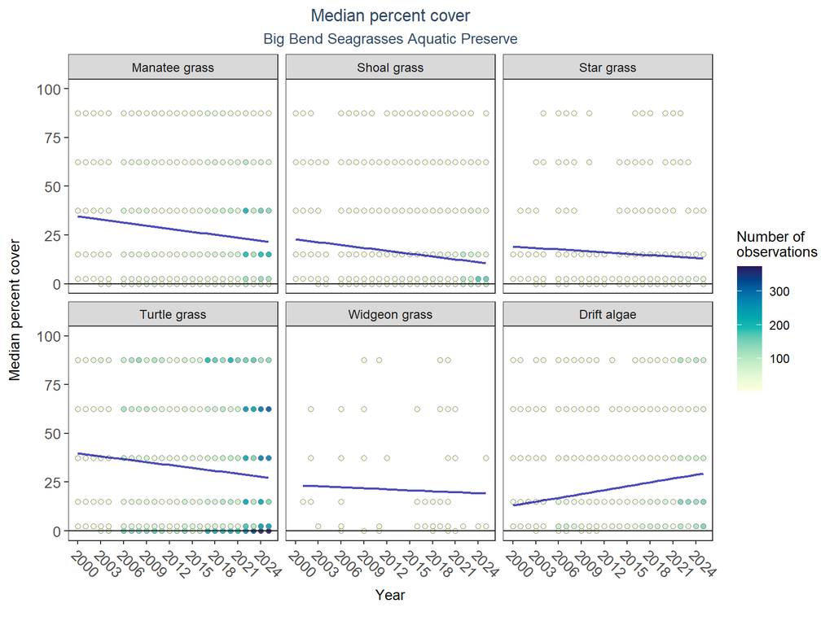

SAV LME Results for Big Bend Seagrasses Aquatic Preserve

| Species | Statistical Trend | Period of Record | LME Intercept | LME Slope | p |
| --- | --- | --- | --- | --- | --- |
| Drift algae | Increasing trend | 2000 - 2025 | 9.03 | 0.66 | 0.00 |
| Shoal grass | Decreasing trend | 2000 - 2025 | 25.78 | -0.49 | 0.00 |
| Star grass | No detectable trend | 2000 - 2025 | 20.62 | -0.25 | 0.05 |
| Widgeon grass | No detectable trend | 2001 - 2025 | 24.41 | -0.17 | 0.71 |
| Manatee grass | Decreasing trend | 2000 - 2025 | 37.79 | -0.53 | 0.00 |
| Turtle grass | Decreasing trend | 2000 - 2025 | 42.68 | -0.49 | 0.00 |

An annual increase in percent cover was observed for drift algae (0.66%). Annual decreases in percent cover were observed for manatee grass (-0.53%), shoal grass (-0.49%), and turtle grass (-0.49%). No detectable change in percent cover was observed for star grass and widgeon grass.

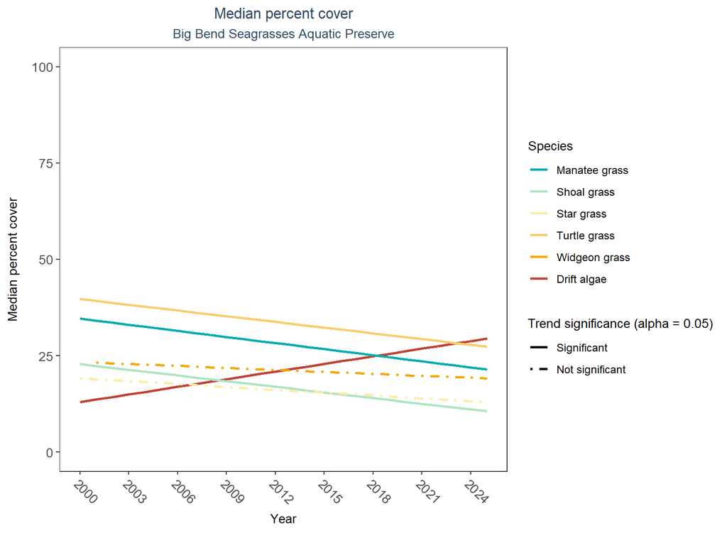

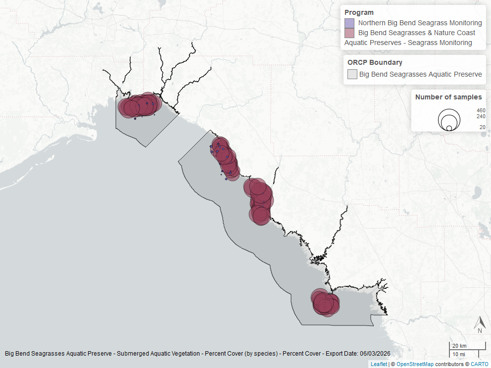

Map showing SAV sampling sites within the boundaries of *Big Bend Seagrasses Aquatic Preserve*. The point size reflects the number of samples at a given sampling site.

# Biscayne Bay Aquatic Preserve

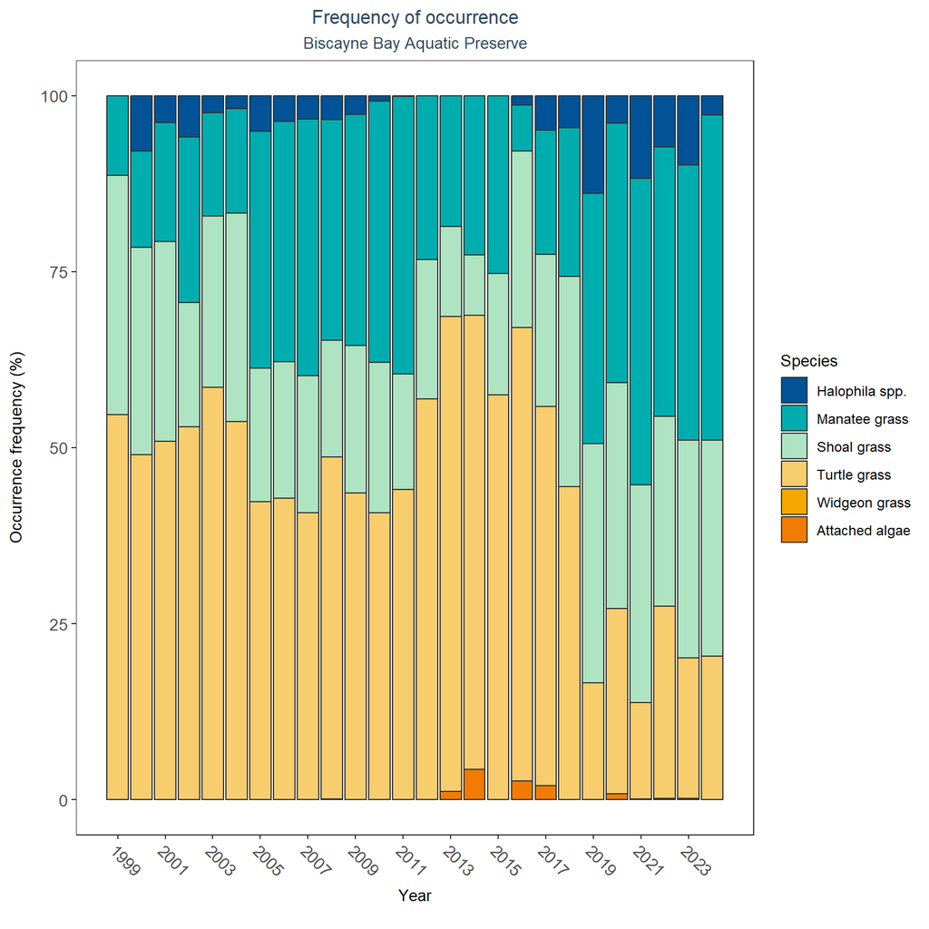

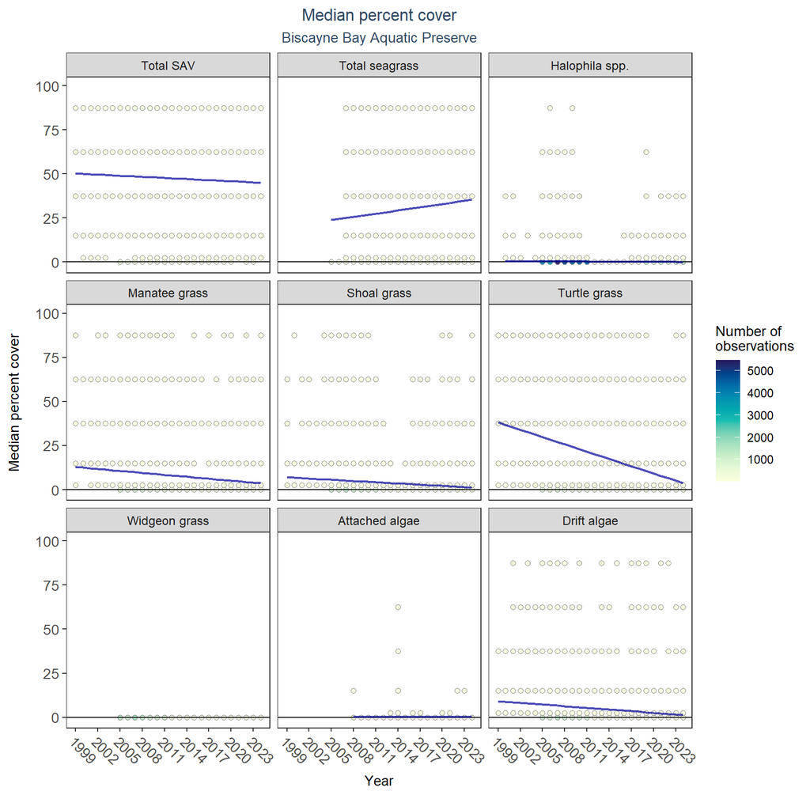

SAV LME Results for Biscayne Bay Aquatic Preserve

| Species | Statistical Trend | Period of Record | LME Intercept | LME Slope | p |
| --- | --- | --- | --- | --- | --- |
| Attached algae | No detectable trend | 2008 - 2024 | -0.03 | 0.01 | 0.10 |
| Drift algae | Decreasing trend | 1999 - 2024 | 10.73 | -0.31 | 0.00 |
| Shoal grass | Decreasing trend | 1999 - 2024 | 8.21 | -0.23 | 0.00 |
| Halophila spp. | Decreasing trend | 2000 - 2024 | 0.67 | -0.02 | 0.01 |
| Widgeon grass | Model did not fit the available data | 2005 - 2024 | - | - | - |
| Manatee grass | Decreasing trend | 1999 - 2024 | 14.75 | -0.37 | 0.00 |
| Turtle grass | Decreasing trend | 1999 - 2024 | 44.97 | -1.37 | 0.00 |
| Total SAV | No detectable trend | 1999 - 2024 | 51.24 | -0.21 | 0.26 |
| Total seagrass | Increasing trend | 2005 - 2024 | 17.14 | 0.61 | 0.00 |

An annual increase in percent cover was observed for total seagrass (0.61%). Annual decreases in percent cover were observed for *Halophila* spp. (-0.02%), manatee grass (-0.37%), shoal grass (-0.23%), turtle grass (-1.37%), and drift algae (-0.31%). No detectable change in percent cover was observed for total SAV and attached algae. The model could not be fitted for widgeon grass.

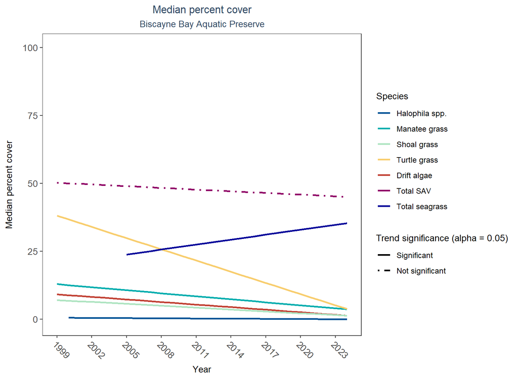

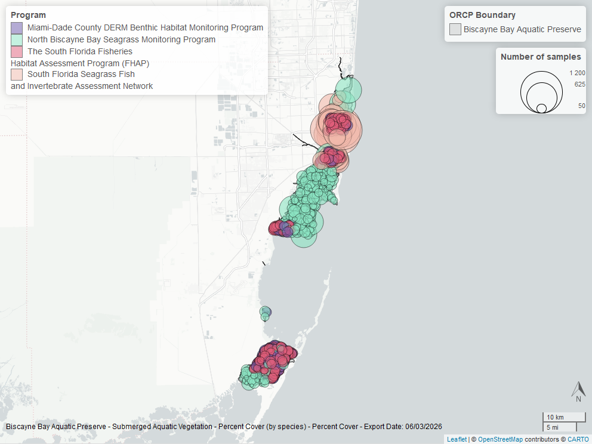

Map showing SAV sampling sites within the boundaries of *Biscayne Bay Aquatic Preserve*. The point size reflects the number of samples at a given sampling site.

# Boca Ciega Bay Aquatic Preserve

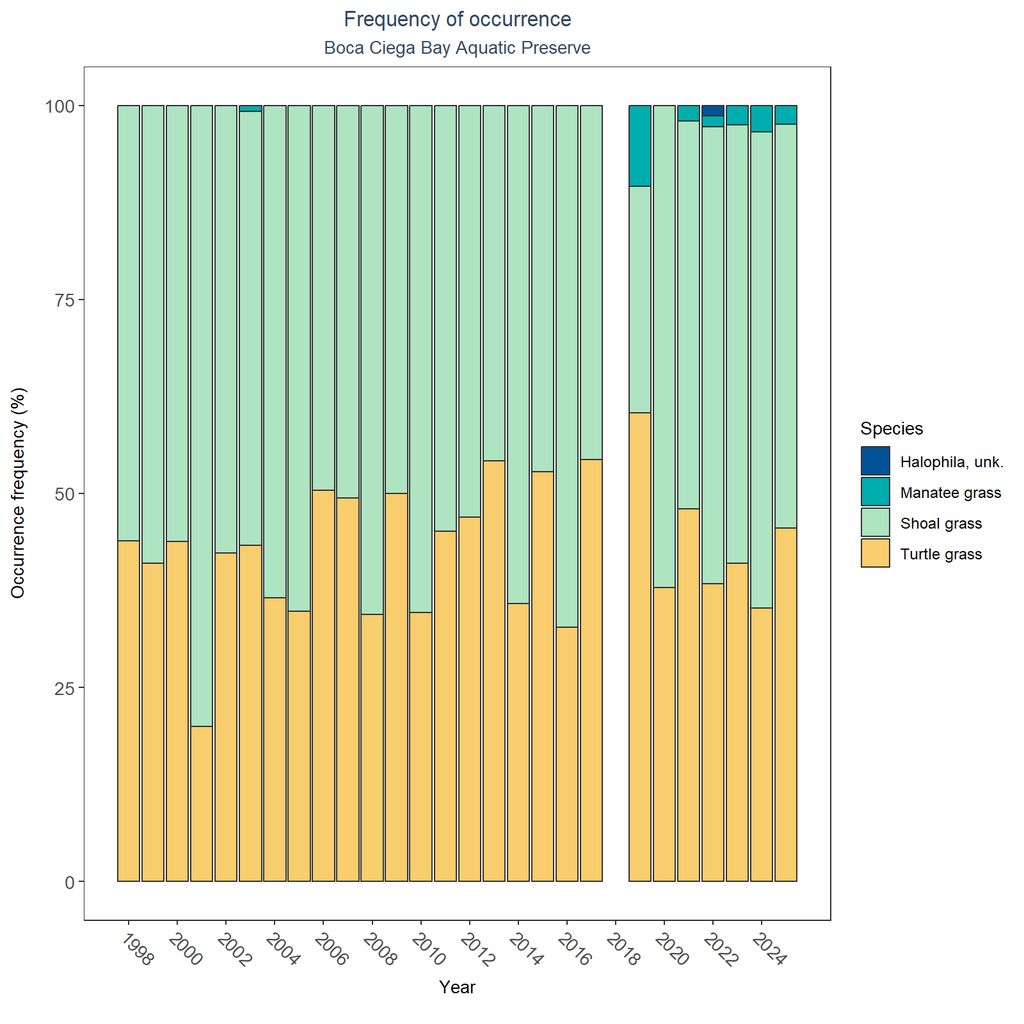

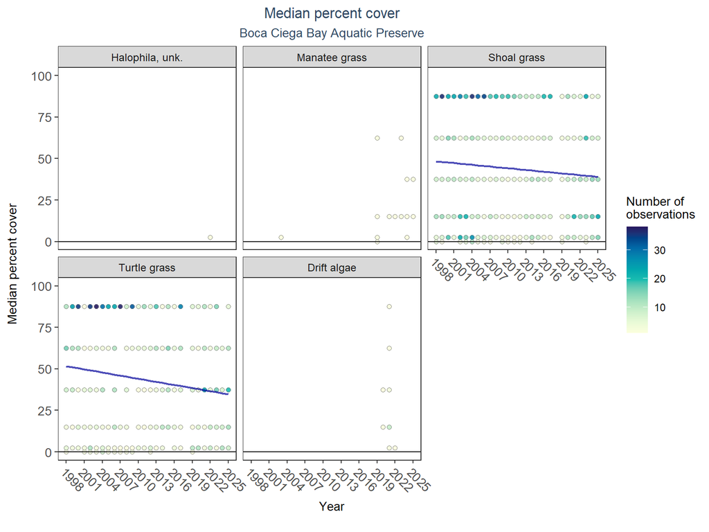

SAV LME Results for Boca Ciega Bay Aquatic Preserve

| Species | Statistical Trend | Period of Record | LME Intercept | LME Slope | p |
| --- | --- | --- | --- | --- | --- |
| Drift algae | Insufficient data | 2020 - 2022 | - | - | - |
| Shoal grass | No detectable trend | 1998 - 2025 | 49.73 | -0.35 | 0.05 |
| Manatee grass | Model did not fit the available data | 2003 - 2025 | - | - | - |
| Turtle grass | Decreasing trend | 1998 - 2025 | 54.11 | -0.63 | 0.02 |
| Halophila, unk. | Insufficient data | 2022 - 2022 | - | - | - |

An annual decrease in percent cover was observed for turtle grass (-0.63%). No detectable change in percent cover was observed for shoal grass. Trends in percent cover could not be evaluated for unknown *Halophila* and drift algae due to insufficient data, and the model could not be fitted for manatee grass.

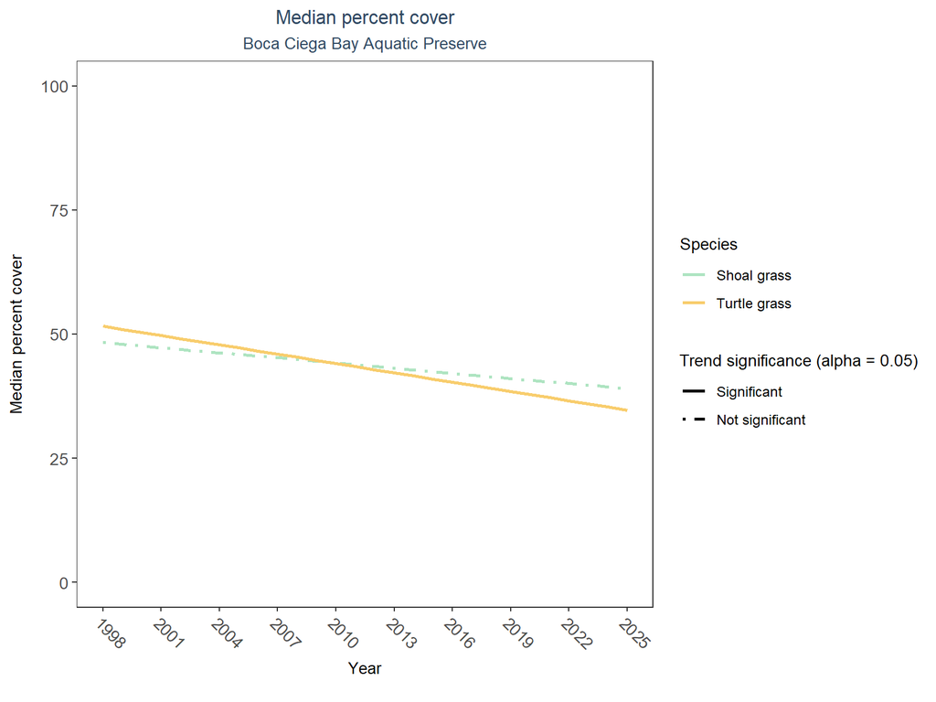

[figure not shown]

Map showing SAV sampling sites within the boundaries of *Boca Ciega Bay Aquatic Preserve*. The point size reflects the number of samples at a given sampling site.

# Cape Haze Aquatic Preserve

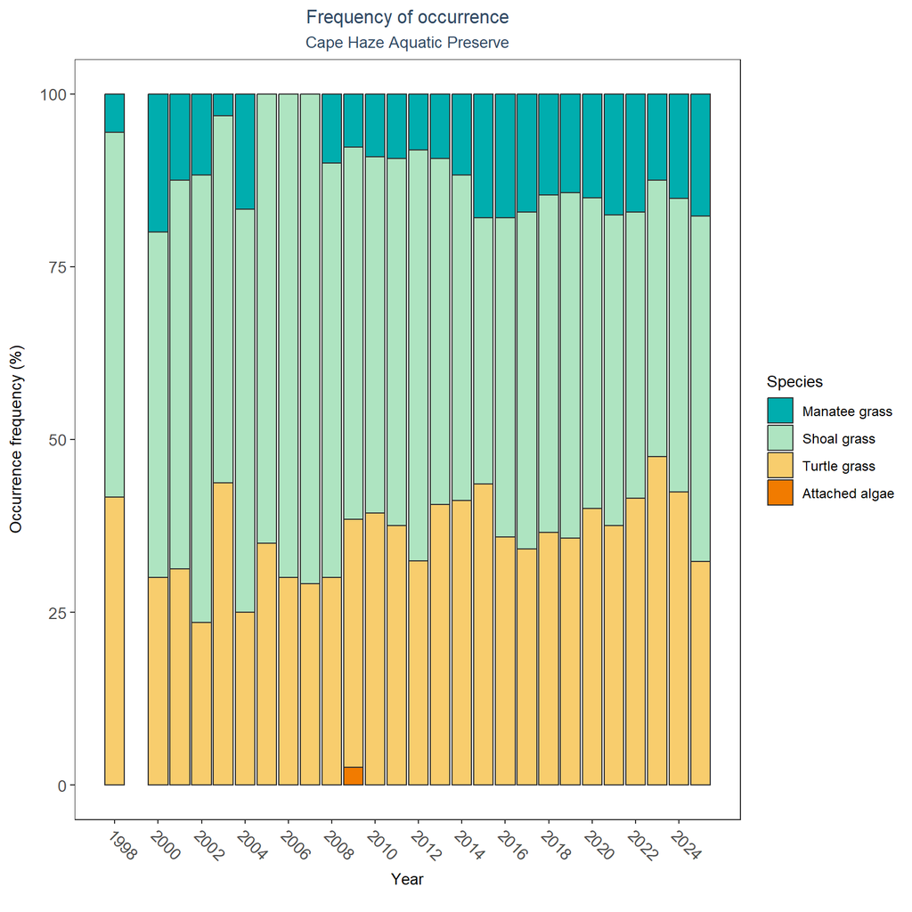

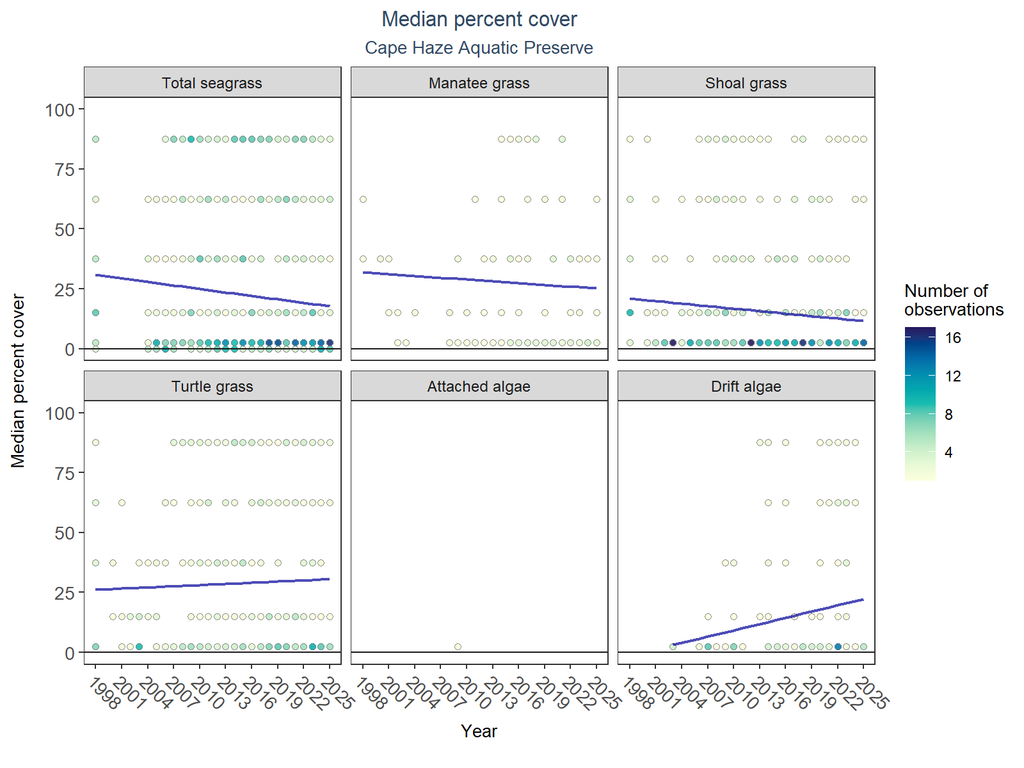

SAV LME Results for Cape Haze Aquatic Preserve

| Species | Statistical Trend | Period of Record | LME Intercept | LME Slope | p |
| --- | --- | --- | --- | --- | --- |
| Attached algae | Insufficient data | 2009 - 2009 | - | - | - |
| Drift algae | No detectable trend | 2003 - 2025 | -4.73 | 0.87 | 0.12 |
| Shoal grass | No detectable trend | 1998 - 2025 | 22.33 | -0.35 | 0.28 |
| Manatee grass | No detectable trend | 1998 - 2025 | 32.87 | -0.25 | 0.74 |
| Turtle grass | No detectable trend | 1998 - 2025 | 25.49 | 0.16 | 0.62 |
| Total seagrass | No detectable trend | 1998 - 2025 | 32.72 | -0.48 | 0.21 |

Total seagrass, manatee grass, shoal grass, turtle grass, and drift algae showed no detectable change in percent cover. Trends in percent cover could not be evaluated for attached algae due to insufficient data.

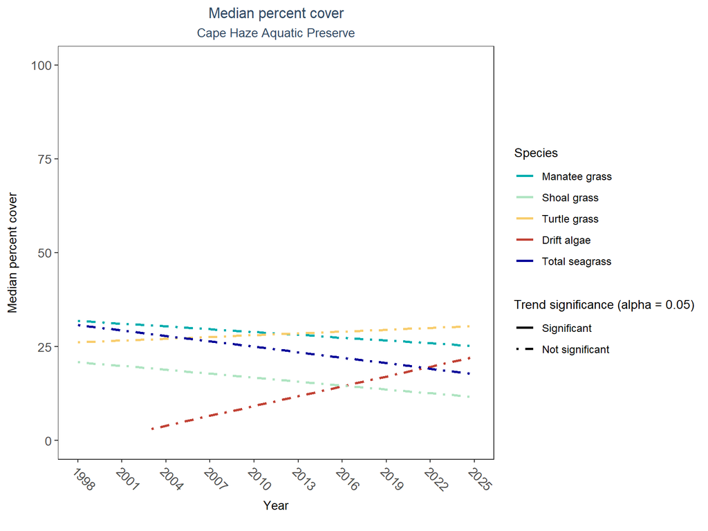

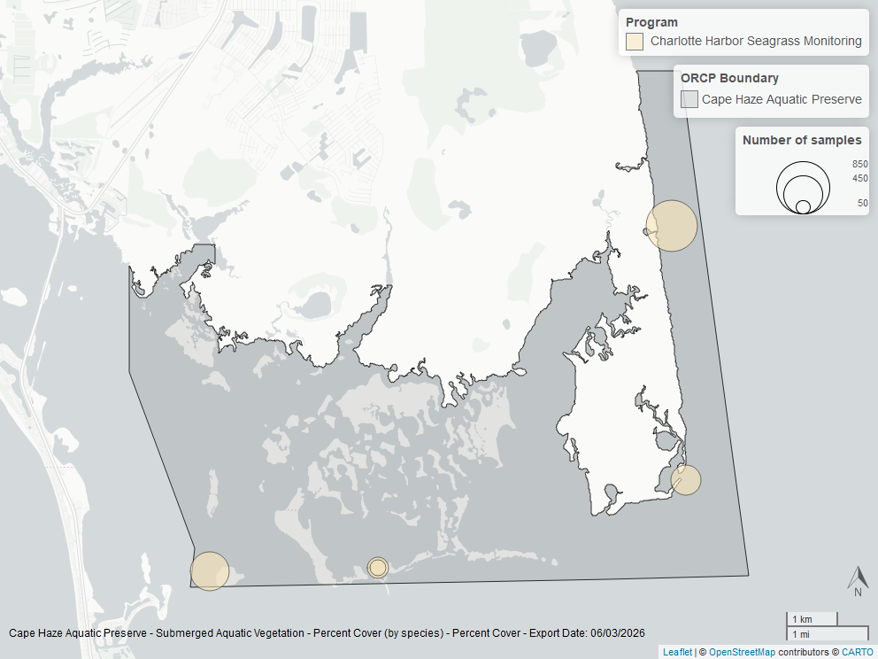

Map showing SAV sampling sites within the boundaries of *Cape Haze Aquatic Preserve*. The point size reflects the number of samples at a given sampling site.